# STAT 6302 Final Project

Author

Jack Motta

# Overview

## Attributes

- 53,940 diamonds w/ 11 variables
- Original Predictors:
  - Carat
  - Cut
  - Color: From “J” (worst) to “D” (best)
  - Clarity:
    - From worst to best: I1, SI2, SI1, VS2, VS1, VVS2, VVS1, IF
  - Length (x), width (y), and depth (z) in mm
  - Total depth percentage (depth) $= 2 * z / (x + y)$
  - Table: width of top of diamond relative to widest point
- Outcome is price
- 9 predictors (w/ feature engineering and not including ID variable)
- Technically no missing values
- Apparent data entry error for x, y, and z due to having values of zero, so set them to equal “NA” and then use KNN imputation. 35 total missing values after setting them equal to NA.

## Objective

- Build accurate predictive price model
- Compare Boosting vs Random Forest vs Penalized Regression model
- Prediction over inference

## Methodology

### Feature Engineering

- Created approx. volume: $length * width * depth$. Captures the overall size of the diamond, which is likely to have a significant impact on the diamond’s price and overall quality.
- Use aspect ratio ($length/width$) to approximate the diamond’s shape using the common aspect ratios for each shape.
  - Then create shape
- Approx. Surface Area: $4\pi((x^py^p + x^pz^p + y^pz^p) / 3)^{(1/p)}$ where $p=1.6075$, x = length, y = width, and z = depth.
  - Approximates the diamond as an ellipsoid (assuming ellipsoid to simplify complex facet of the diamonds). The surface area might correlate with the diamond’s brilliance and sparkle as it relates to how much light can interact with the surface, potentially affecting its desirability and price.
- Rename ID variable from “X” to “ID”

### Preprocessing Steps (RF and XGB)

- Update role ID
- Mutate feature engineering (aspect ratio, shape, volume, surface area)
- KNN imputation for length (x), width (y), and depth (z) due to certain diamonds having values of 0 for them which isn’t possible, so likely data entry error
- Use aspect ratio to determine shape and then remove aspect ratio as a predictor along with x, y, and z
- Normalize all numeric predictors
- One hot dummy encoding all nominal predictors

### Model Tuning

- Grid size of 5 to make it less computationally extensive
- Random Forest: tuning minimum node size, set trees equal to 500, and set number of predictors randomly sampled to 3 because $9/3=3$)
- XGBoost: Tuning max depth of each tree, learning rate, minimum amount of loss reduction, size of subsample, minimum node size, and max number of boosting iterations, while also setting trees equal to 500 and number of predictors randomly samples to 3
- Penalized Regression: Elastic Net, tuning both penalty and mixture.

# Library

```r
library(tidymodels)
library(tidyverse)
library(dplyr)
library(vip)
library(iml)
library(ggplot2)
library(xgboost)
library(ranger)
library(ggthemes)
library(doParallel)
library(themis)
library(future)
library(future.callr)
library(finetune)
library(probably)
library(pdp)
library(yardstick)
library(gtsummary)
library(gridExtra)
library(dials)
library(rpart)
library(rpart.plot)
```

# Load Data

```r
# Load the dataset
diamonds <- read.csv("C:/Users/jgmot/OneDrive/Documents/Data Projects/Kaggle Datasets/diamonds.csv")

# Rename X to ID
diamonds <- diamonds %>%
  rename(ID = X)

# Convert Character variables into factors
diamonds$cut <- as.factor(diamonds$cut)
diamonds$color <- as.factor(diamonds$color)
diamonds$clarity <- as.factor(diamonds$clarity)

# Diamonds can't have zero dimensions if they exist
zero_dimensions <- diamonds[diamonds$x == 0 | diamonds$y == 0 | diamonds$z == 0, ]
print(zero_dimensions)
```

```
         ID carat       cut color clarity depth table price    x    y z
2208   2208  1.00   Premium     G     SI2  59.1    59  3142 6.55 6.48 0
2315   2315  1.01   Premium     H      I1  58.1    59  3167 6.66 6.60 0
4792   4792  1.10   Premium     G     SI2  63.0    59  3696 6.50 6.47 0
5472   5472  1.01   Premium     F     SI2  59.2    58  3837 6.50 6.47 0
10168 10168  1.50      Good     G      I1  64.0    61  4731 7.15 7.04 0
11183 11183  1.07     Ideal     F     SI2  61.6    56  4954 0.00 6.62 0
11964 11964  1.00 Very Good     H     VS2  63.3    53  5139 0.00 0.00 0
13602 13602  1.15     Ideal     G     VS2  59.2    56  5564 6.88 6.83 0
15952 15952  1.14      Fair     G     VS1  57.5    67  6381 0.00 0.00 0
24395 24395  2.18   Premium     H     SI2  59.4    61 12631 8.49 8.45 0
24521 24521  1.56     Ideal     G     VS2  62.2    54 12800 0.00 0.00 0
26124 26124  2.25   Premium     I     SI1  61.3    58 15397 8.52 8.42 0
26244 26244  1.20   Premium     D    VVS1  62.1    59 15686 0.00 0.00 0
27113 27113  2.20   Premium     H     SI1  61.2    59 17265 8.42 8.37 0
27430 27430  2.25   Premium     H     SI2  62.8    59 18034 0.00 0.00 0
27504 27504  2.02   Premium     H     VS2  62.7    53 18207 8.02 7.95 0
27740 27740  2.80      Good     G     SI2  63.8    58 18788 8.90 8.85 0
49557 49557  0.71      Good     F     SI2  64.1    60  2130 0.00 0.00 0
49558 49558  0.71      Good     F     SI2  64.1    60  2130 0.00 0.00 0
51507 51507  1.12   Premium     G      I1  60.4    59  2383 6.71 6.67 0
```

```r
diamonds$x[diamonds$x == 0] <- NA
diamonds$y[diamonds$y == 0] <- NA
diamonds$z[diamonds$z == 0] <- NA
sum(is.na(diamonds))
```

```
[1] 35
```

# Outlier Investigation

```r
diamonds[c(24066:24070),c(9:11)] # outlier at 24068 for measurements
```

```
         x     y    z
24066 8.08  8.03 5.05
24067 8.15  8.10 4.93
24068 8.09 58.90 8.06
24069 7.45  7.43 4.52
24070 7.03  6.98 4.26
```

```r
diamonds[c(48409:48413),c(9:11)] # outlier at 48411 for measurements
```

```
         x    y     z
48409 5.75 5.78  3.61
48410 5.64 5.68  3.56
48411 5.12 5.15 31.80
48412 5.07 5.10  3.20
48413 5.39 5.43  3.35
```

```r
diamonds[c(49188:49192),c(9:11)] # outlier at 49190 for measurements
```

```
         x     y    z
49188 5.58  5.50 3.30
49189 5.60  5.49 3.62
49190 5.15 31.80 5.12
49191 5.67  5.70 3.55
49192 5.72  5.78 3.53
```

```r
# Set equal to NAs and use KNN Imputation to resolve

diamonds$x[diamonds$x > 30] <- NA
diamonds$y[diamonds$y > 30] <- NA
diamonds$z[diamonds$z > 30] <- NA
```

# Feature Engineering

```r
# Set p to common value used for approximating ellipsoid surface area
p <- 1.6075
# Calculate aspect ratio for each diamond
diamonds <- diamonds %>%
  mutate(
    volume = x * y * z,
    aspect_ratio = round(x / y, 2),
    surface_area = 4 * pi * ((x^p * y^p + x^p * z^p + y^p * z^p) / 3)^(1/p),
    shape = as.factor(case_when(
      aspect_ratio == 1 ~ "Round",
      aspect_ratio > 1 & aspect_ratio <= 1.05 ~ "Princess",
      aspect_ratio <= 1.10 & aspect_ratio != 1 ~ "Heart",
      (aspect_ratio >= 1.3 & aspect_ratio <= 1.5) ~ "Oval",
      (aspect_ratio >= 1.85 & aspect_ratio <= 2.1) ~ "Marquise",
      (aspect_ratio >= 1.45 & aspect_ratio <= 1.75) ~ "Pear",
      (aspect_ratio >= 1.3 & aspect_ratio <= 1.6) ~ "Emerald",
      (aspect_ratio > 1 & aspect_ratio <= 1.05) ~ "Asscher",
      (aspect_ratio > 1 & aspect_ratio <= 1.30) ~ "Cushion",
      (aspect_ratio > 1 & aspect_ratio <= 1.35) ~ "Radiant",
      TRUE ~ "Unknown"  # Fallback case
  ))) %>%
  select(-c(x, y, z, aspect_ratio)) # Exclude from summary
```

# Summary Table

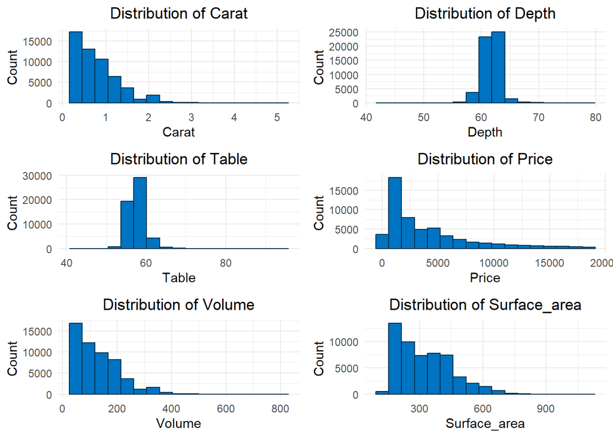

```r
summary_data <- diamonds %>%
  select(-ID)

# Plot distributions
num_bins <- function(n) ceiling(1 + log2(n))
hist_plots <- lapply(names(summary_data)[sapply(summary_data, is.numeric)], function(var) {
  ggplot(summary_data, aes_string(x = var)) +
    geom_histogram(bins = num_bins(nrow(summary_data)), fill = "#0073C2FF", color = "#003350") +
    labs(title = paste("Distribution of", str_to_title(var)),
         x = str_to_title(var),
         y = "Count") +
    theme_minimal() +
    theme(plot.title = element_text(hjust = 0.5))
})
do.call(grid.arrange, c(hist_plots, ncol = 2))
```

```r
summary_table <- tbl_summary(
  data = summary_data,
  by = NULL, # No grouping variable since we want a summary of the entire dataset
  type = list(
    carat ~ "continuous2",
    depth ~ "continuous2",
    table ~ "continuous2",
    price ~ "continuous2",
    volume ~ "continuous2",
    surface_area ~ "continuous2",
    all_categorical() ~ "categorical"),
  statistic = list(
    carat ~ c("{median}","{IQR}"),
    price ~ c("{median}","{IQR}"),
    volume ~ c("{median}","{IQR}"),
    surface_area ~ c("{median}","{IQR}"),
    depth ~ c("{mean}", "{sd}"),
    table ~ c("{mean}", "{sd}"),
    all_categorical() ~ "{p}% ({n})"),
  missing_text = "No. of NAs",
  label = list(
    carat = "Carat",
    cut = "Cut",
    color = "Color",
    clarity = "Clarity",
    depth = "Total Depth Percentage",
    table = "Width of Top of Diamond",
    volume = "Volume",
    surface_area = "Surface Area",
    shape = "Shape",
    price = "Price"
  )) %>%
  as_gt() %>%
  gt::tab_header(
    title = "**Table 1: Diamond Summary Statistics**")
summary_table
```

**Table 1: Diamond Summary Statistics**

| **Characteristic** | **N = 53,940**<sup>1</sup> |
| --- | --- |
| Carat |  |
| Median | 0.70 |
| IQR | 0.64 |
| Cut |  |
| Fair | 3.0% (1,610) |
| Good | 9.1% (4,906) |
| Ideal | 40% (21,551) |
| Premium | 26% (13,791) |
| Very Good | 22% (12,082) |
| Color |  |
| D | 13% (6,775) |
| E | 18% (9,797) |
| F | 18% (9,542) |
| G | 21% (11,292) |
| H | 15% (8,304) |
| I | 10% (5,422) |
| J | 5.2% (2,808) |
| Clarity |  |
| I1 | 1.4% (741) |
| IF | 3.3% (1,790) |
| SI1 | 24% (13,065) |
| SI2 | 17% (9,194) |
| VS1 | 15% (8,171) |
| VS2 | 23% (12,258) |
| VVS1 | 6.8% (3,655) |
| VVS2 | 9.4% (5,066) |
| Total Depth Percentage |  |
| Mean | 61.75 |
| SD | 1.43 |
| Width of Top of Diamond |  |
| Mean | 57.46 |
| SD | 2.23 |
| Price |  |
| Median | 2,401 |
| IQR | 4,374 |
| Volume |  |
| Median | 115 |
| IQR | 106 |
| No. of NAs | 23 |
| Surface Area |  |
| Median | 310 |
| IQR | 192 |
| No. of NAs | 23 |
| Shape |  |
| Cushion | <0.1% (6) |
| Heart | 44% (23,666) |
| Oval | <0.1% (2) |
| Pear | <0.1% (3) |
| Princess | 35% (19,007) |
| Round | 21% (11,246) |
| Unknown | <0.1% (10) |

<sup>1</sup> % (n)

# Data Split

```r
# Training-Test Split
set.seed(6302)
diamonds_split <- initial_split(diamonds, prop = 0.70, strata = price)
diamonds_train <- training(diamonds_split)
diamonds_test  <-  testing(diamonds_split)
# Set k rule of thumb
k_rule_of_thumb <- round(sqrt(nrow(diamonds_train)))

set.seed(6302)
cv_folds <- vfold_cv(diamonds_train, v = 10, repeats = 5, strata = price)

# Prepare the recipe
diamonds_recipe <- recipe(price ~ ., data = diamonds_train) %>%
  update_role(ID, new_role = "ID") %>%
  step_impute_knn(all_predictors(), neighbors = k_rule_of_thumb) %>%
  step_normalize(all_numeric_predictors()) %>%
  step_dummy(all_nominal_predictors(), -all_outcomes(), one_hot = TRUE)

ncores <- 6
```

# Model Building

## Random Forest Model

```r
rm(hist_plots, p, num_bins, summary_table, zero_dimensions, diamonds)

# Define the model specification
rf_model <- rand_forest(trees = 500, mtry = 3, min_n = tune()) %>%
            set_engine("ranger", importance = "impurity") %>%
            set_mode("regression")
rf_wflow <- workflow() %>%
  add_model(rf_model) %>%
  add_recipe(diamonds_recipe)

# Use space filling design
rf_param <- extract_parameter_set_dials(rf_model) %>%
  dials::finalize(juice(prep(diamonds_recipe)))
glh_rf <- grid_latin_hypercube(rf_param, size = 5)
# Model Tuning w/ parallel processing
#cl <- makeCluster(ncores)
#registerDoParallel(cl)
#set.seed(6302)
#rf_tune <- tune_grid(
#  rf_wflow,
#  resamples = cv_folds,
#  grid = glh_rf)
#stopCluster(cl)
#registerDoSEQ()
#saveRDS(rf_tune, 'C:/Users/jgmot/OneDrive/Documents/Data Projects/Kaggle Datasets/rf_tune1.rds')
rf_tune <- readRDS( 'C:/Users/jgmot/OneDrive/Documents/Data Projects/Kaggle Datasets/rf_tune1.rds')

# Select the best model
best_rf_params <- select_best(rf_tune, metric = "rmse")
best_rf_params
```

```
# A tibble: 1 × 2
  min_n .config
  <int> <chr>
1     7 Preprocessor1_Model5
```

```r
# Finalize model
rf_model2 <- finalize_model(rf_model, best_rf_params)
# Update workflow
rf_wflow2 <- rf_wflow %>%
  update_model(rf_model2)

# Fit Resamples
#ctrl <- control_resamples(save_pred = TRUE)
#resamples_rf <- fit_resamples(
#              rf_wflow2,
#              resamples = cv_folds,
#              control = ctrl,
#              metrics = metric_set(rmse, mae, rsq))
#saveRDS(resamples_rf, 'C:/Users/jgmot/OneDrive/Documents/Data Projects/Kaggle Datasets/resamples_rf1.rds')
resamples_rf <- readRDS( 'C:/Users/jgmot/OneDrive/Documents/Data Projects/Kaggle Datasets/resamples_rf1.rds')
resamples_rf %>% collect_metrics()
```

```
# A tibble: 3 × 6
  .metric .estimator    mean     n  std_err .config
  <chr>   <chr>        <dbl> <int>    <dbl> <chr>
1 mae     standard   600.       50 2.05     Preprocessor1_Model1
2 rmse    standard   981.       50 4.57     Preprocessor1_Model1
3 rsq     standard     0.955    50 0.000310 Preprocessor1_Model1
```

```r
# Last Fit
#final_rf_fit <- last_fit(rf_wflow2, diamonds_split,
#                         metrics = metric_set(yardstick::rmse, yardstick::mae, yardstick::rsq))
#saveRDS(final_rf_fit, 'C:/Users/jgmot/OneDrive/Documents/Data Projects/Kaggle Datasets/final_rf_fit1.rds')
final_rf_fit <- readRDS( 'C:/Users/jgmot/OneDrive/Documents/Data Projects/Kaggle Datasets/final_rf_fit1.rds')
final_rf_fit %>% collect_metrics()
```

```
# A tibble: 3 × 4
  .metric .estimator .estimate .config
  <chr>   <chr>          <dbl> <chr>
1 rmse    standard     951.    Preprocessor1_Model1
2 mae     standard     582.    Preprocessor1_Model1
3 rsq     standard       0.958 Preprocessor1_Model1
```

```r
# Extract the fit for interpretable ML
rf_engine <- extract_fit_engine(final_rf_fit)
rf_juice <- juice(prep(diamonds_recipe))
rf.price <- rf_juice$price
diamonds_data.rf <- rf_juice %>%
  select(-ID, -price)

# IML setup for ranger
pfun.ranger <- function(model, newdata) {
  predict(model, data = newdata, type = "response")$predictions
}
predictor.rf <- Predictor$new(
  model = rf_engine,
  data = diamonds_data.rf,
  y = rf.price,
  predict.fun = pfun.ranger)
```

## XGBoost

```r
rm(resamples_rf, rf_juice, best_rf_params, glh_rf, rf_param, rf_model, rf_wflow, rf_tune)

xgb_model <- boost_tree(
                  mode = "regression", mtry = 3, trees = 500, tree_depth = tune(),
                  min_n = tune(), loss_reduction = tune(), learn_rate = tune(),
                  sample_size = tune(), stop_iter = tune()) %>%
                  set_mode("regression") %>%
                  set_engine("xgboost")
xgb_wf <- workflow() %>%
                    add_recipe(diamonds_recipe) %>%
                    add_model(xgb_model)

boost_param <- extract_parameter_set_dials(xgb_model) %>%
  dials::finalize(juice(prep(diamonds_recipe, training = diamonds_train)))
glh_boost <- grid_latin_hypercube(boost_param, size = 5)

# Tune parameters
#cl <- makeCluster(ncores)
#registerDoParallel(cl)
#set.seed(6302)
#xgb_tune <- tune_grid(
#   xgb_wf,
#   resamples = cv_folds,
#   grid = glh_boost)
#stopCluster(cl)
#registerDoSEQ()
#saveRDS(xgb_tune, 'C:/Users/jgmot/OneDrive/Documents/Data Projects/Kaggle Datasets/xgb_tune.rds1')
xgb_tune <- readRDS( 'C:/Users/jgmot/OneDrive/Documents/Data Projects/Kaggle Datasets/xgb_tune.rds1')
# Show optimal tuning parameters
xgb_param <- xgb_tune %>% select_best(metric = "rmse")
xgb_param
```

```
# A tibble: 1 × 7
  min_n tree_depth learn_rate loss_reduction sample_size stop_iter .config
  <int>      <int>      <dbl>          <dbl>       <dbl>     <int> <chr>
1    13          8     0.0711           1.71       0.838        14 Preprocessor…
```

```r
# Finalize Model
xgb_model2 <- finalize_model(xgb_model, xgb_param)
# Update Workflow
xgb_wflow2 <- xgb_wf %>%
  update_model(xgb_model2)

# Fit Resamples
#resamples_xgb <- fit_resamples(
#              xgb_wflow2,
#              resamples = cv_folds,
#              control = ctrl,
#              metrics = metric_set(rmse, mae, rsq))
#saveRDS(resamples_xgb, 'C:/Users/jgmot/OneDrive/Documents/Data Projects/Kaggle Datasets/resamples_xgb.rds1')
resamples_xgb <- readRDS( 'C:/Users/jgmot/OneDrive/Documents/Data Projects/Kaggle Datasets/resamples_xgb.rds1')
resamples_xgb %>% collect_metrics()
```

```
# A tibble: 3 × 6
  .metric .estimator    mean     n  std_err .config
  <chr>   <chr>        <dbl> <int>    <dbl> <chr>
1 mae     standard   291.       50 0.996    Preprocessor1_Model1
2 rmse    standard   556.       50 2.51     Preprocessor1_Model1
3 rsq     standard     0.981    50 0.000170 Preprocessor1_Model1
```

```r
#final_xgb_fit <- last_fit(xgb_wflow2, diamonds_split,
#                         metrics = metric_set(yardstick::rmse, yardstick::mae, yardstick::rsq))
#saveRDS(final_xgb_fit, 'C:/Users/jgmot/OneDrive/Documents/Data Projects/Kaggle Datasets/final_xgb_fit.rds1')
final_xgb_fit <- readRDS( 'C:/Users/jgmot/OneDrive/Documents/Data Projects/Kaggle Datasets/final_xgb_fit.rds1')
final_xgb_fit %>% collect_metrics()
```

```
# A tibble: 3 × 4
  .metric .estimator .estimate .config
  <chr>   <chr>          <dbl> <chr>
1 rmse    standard     543.    Preprocessor1_Model1
2 mae     standard     285.    Preprocessor1_Model1
3 rsq     standard       0.982 Preprocessor1_Model1
```

```r
xgb_juice <- juice(prep(diamonds_recipe))
xgb_engine <- extract_fit_engine(final_xgb_fit)
diamonds_data.xgb <- xgb_juice %>%
                dplyr::select(-ID, -price)
# IML for XGBoost
pfun.xgb <- function(model, newdata){
  newData_x <- xgb.DMatrix(data.matrix(newdata), missing = NA)
  results <- predict(model, newData_x)
  return(results)
}
xgb_reg.price <- xgb_juice$price
predictor.xgb <- Predictor$new(model = xgb_engine,
                               data = diamonds_data.xgb,
                               y = xgb_reg.price,
                               predict.fun = pfun.xgb)
```

## Penalized Regression (Elastic Net)

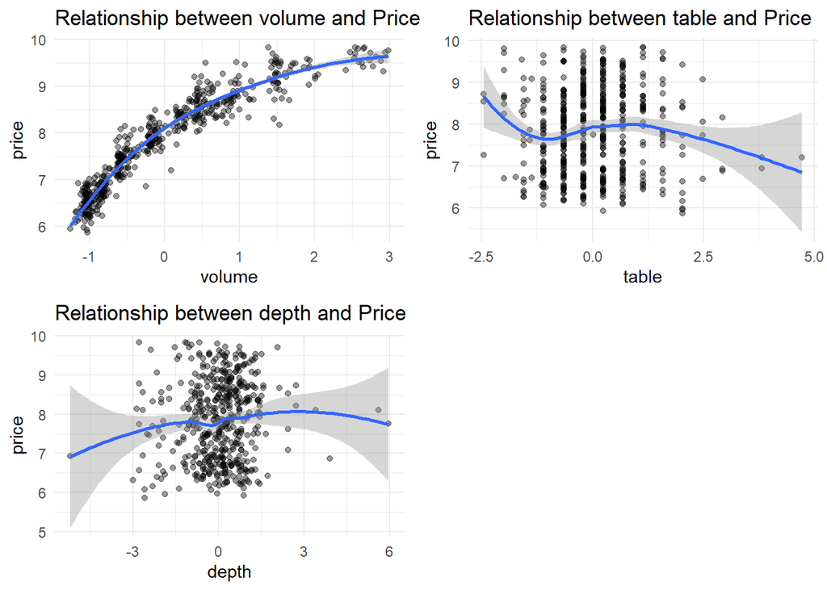

```r
rm(resamples_xgb, xgb_model, xgb_wf, xgb_juice, xgb_param, boost_param, glh_boost, xgb_tune)

glmnet_recipe <- recipe(price ~ ., data = diamonds_train) %>%
  update_role(ID, new_role = "ID") %>%
  step_impute_knn(all_predictors(), neighbors = k_rule_of_thumb) %>%
  step_log(all_outcomes(), offset = 1e-10) %>%
  step_nzv(all_predictors()) %>%
#  step_corr(all_numeric_predictors(), threshold = .8) %>%
  step_normalize(all_numeric_predictors()) %>%
  step_center(all_numeric_predictors()) %>%
  step_scale(all_numeric_predictors()) %>%
  step_dummy(all_nominal_predictors(), -all_outcomes())

# Check loess plots again after recipe
glmnet_baked <- bake(prep(glmnet_recipe), new_data = NULL)
set.seed(6302)
sampled_data <- glmnet_baked %>% sample_n(500)
predictors <- c("volume", "table", "depth")
loess_plots <- lapply(predictors, function(pred) {
  ggplot(sampled_data, aes(x = !!sym(pred), y = !!sym("price"))) +
    geom_point(alpha = 0.4) +
    geom_smooth(method = "loess", formula = y ~ x, span = 0.75) +
    labs(title = paste("Relationship between", pred, "and Price")) +
    theme_minimal()
})
do.call(grid.arrange, c(loess_plots, ncol = 2))
```

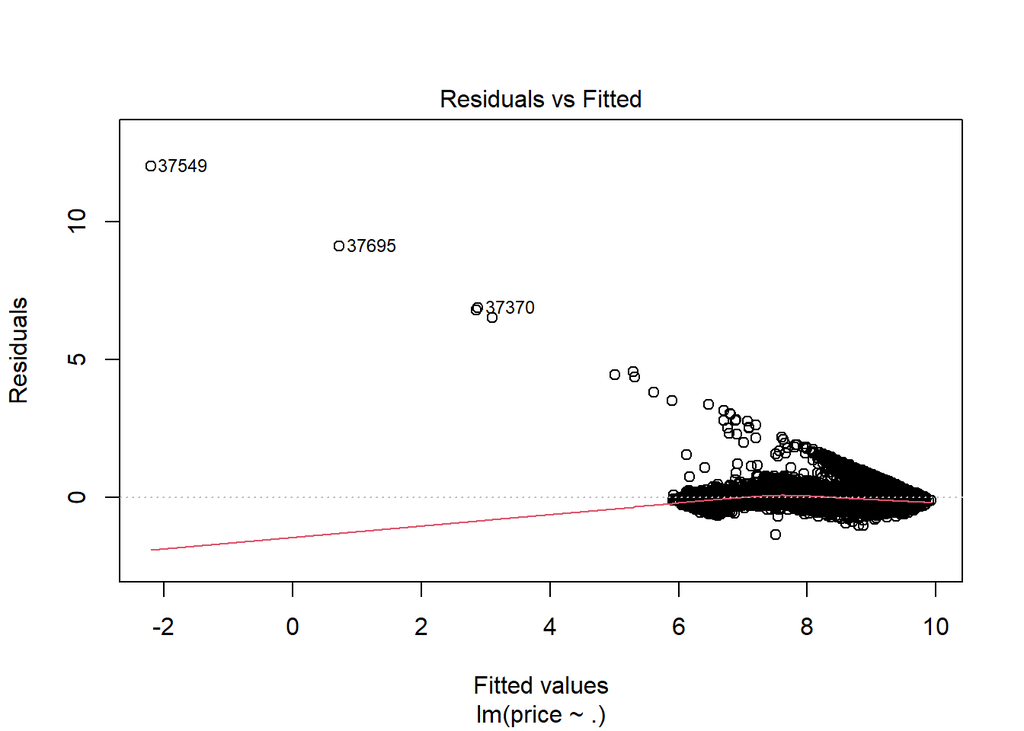

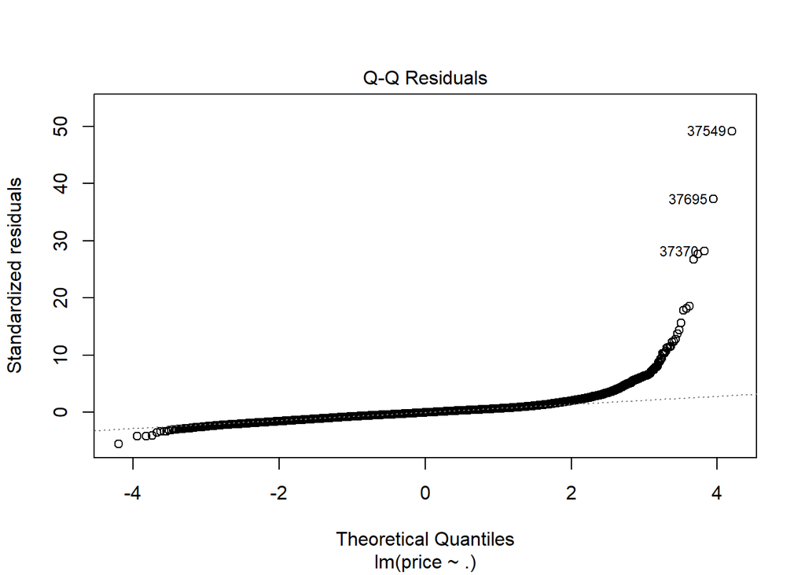

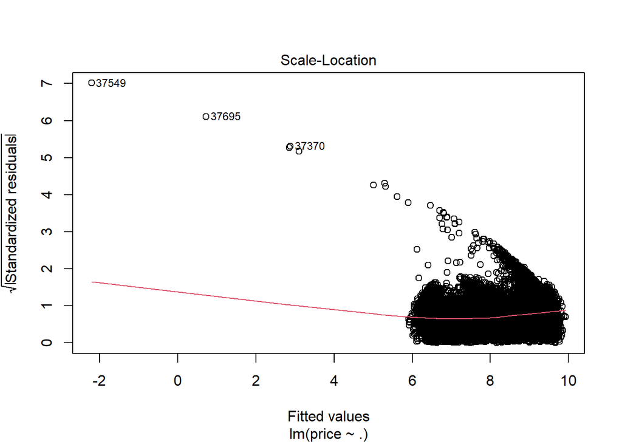

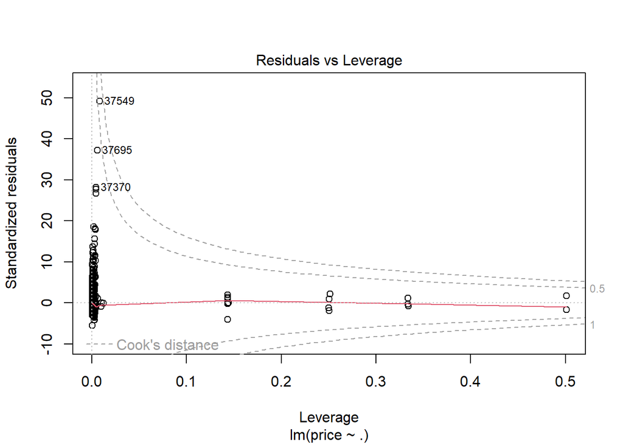

```r
rm(loess_plots, predictors, sampled_data, glmnet_baked)

glmnet_recipe <- recipe(price ~ ., data = diamonds_train) %>%
  update_role(ID, new_role = "ID") %>%
  step_impute_knn(all_predictors(), neighbors = k_rule_of_thumb) %>%
  step_ns(volume, deg_free = 3) %>%
  step_log(all_outcomes(), offset = 1e-10) %>%
  step_nzv(all_predictors()) %>%
  step_corr(all_numeric_predictors(), threshold = .8) %>%
  step_normalize(all_numeric_predictors()) %>%
  step_center(all_numeric_predictors()) %>%
  step_scale(all_numeric_predictors()) %>%
  step_dummy(all_nominal_predictors(), -all_outcomes())

glmnet_baked <- bake(prep(glmnet_recipe), new_data = NULL)
lm.1 <- lm(price ~ ., data = glmnet_baked)
plot(lm.1) # assumptions not met for penalized regression, still proceed but without being able to interpret or generalize results
```

```r
rm(glmnet_baked, lm.1)

glmnet_model <- linear_reg(penalty = tune(), mixture = tune()) %>%
  set_mode("regression") %>%
  set_engine("glmnet")
glmnet_wflow <- workflow() %>%
  add_recipe(glmnet_recipe) %>%
  add_model(glmnet_model)
glmnet_param <- extract_parameter_set_dials(glmnet_model) %>%
  dials::finalize(juice(prep(glmnet_recipe)))
glmnet_glh <- grid_latin_hypercube(glmnet_param, size = 5) # Define a grid of hyperparameters for tuning

# Tune the model w/ parallel processing
#cl <- makeCluster(ncores)
#registerDoParallel(cl)
#set.seed(6302)
#glmnet_tune <- tune_grid(
#  object = glmnet_wflow,
#  resamples = cv_folds,
#  grid = glmnet_glh)
#stopCluster(cl)
#registerDoSEQ()
#saveRDS(glmnet_tune, 'C:/Users/jgmot/OneDrive/Documents/Data Projects/Kaggle Datasets/glmnet_tune.rds')
glmnet_tune <- readRDS( 'C:/Users/jgmot/OneDrive/Documents/Data Projects/Kaggle Datasets/glmnet_tune.rds')
glmnet_best_tune <- select_best(glmnet_tune, metric = "rmse")
glmnet_best_tune
```

```
# A tibble: 1 × 3
   penalty mixture .config
     <dbl>   <dbl> <chr>
1 0.000451   0.169 Preprocessor1_Model1
```

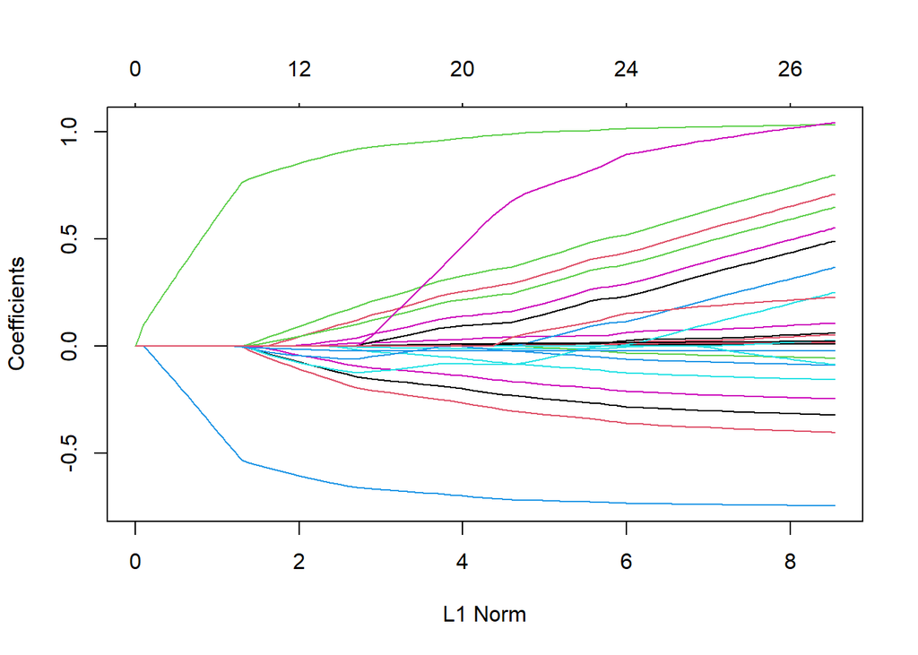

```r
# Update model using optimal parameters
glmnet_model2 <- finalize_model(glmnet_model, glmnet_best_tune)
# Update workflow
glmnet_wflow2 <- glmnet_wflow %>%
  update_model(glmnet_model2)
# Solution path plot
glmnet_path <- glmnet_wflow2 %>%
  fit(diamonds_train) %>%
  extract_fit_parsnip()
plot(glmnet_path$fit)
```

```r
# test model performance with cross-validation
#glmnet_resample <- fit_resamples(
#  glmnet_wflow2,
#  resamples = cv_folds,
#  control = ctrl,
#  metrics = metric_set(yardstick::rmse, yardstick::mae, yardstick::rsq))
#saveRDS(glmnet_resample, 'C:/Users/jgmot/OneDrive/Documents/Data Projects/Kaggle Datasets/glmnet_resample.rds')
glmnet_resample <- readRDS( 'C:/Users/jgmot/OneDrive/Documents/Data Projects/Kaggle Datasets/glmnet_resample.rds')
glmnet_resample %>% collect_metrics()
```

```
# A tibble: 3 × 6
  .metric .estimator  mean     n std_err .config
  <chr>   <chr>      <dbl> <int>   <dbl> <chr>
1 mae     standard   0.169    50 0.00249 Preprocessor1_Model1
2 rmse    standard   0.258    50 0.00669 Preprocessor1_Model1
3 rsq     standard   0.934    50 0.00403 Preprocessor1_Model1
```

```r
#glmnet_last_fit <- last_fit(glmnet_wflow2, diamonds_split,
#                         metrics = metric_set(yardstick::rmse, yardstick::mae, yardstick::rsq))
#saveRDS(glmnet_last_fit, 'C:/Users/jgmot/OneDrive/Documents/Data Projects/Kaggle Datasets/glmnet_last_fit.rds')
glmnet_last_fit <- readRDS( 'C:/Users/jgmot/OneDrive/Documents/Data Projects/Kaggle Datasets/glmnet_last_fit.rds')
glmnet_last_fit %>% collect_metrics()
```

```
# A tibble: 3 × 4
  .metric .estimator .estimate .config
  <chr>   <chr>          <dbl> <chr>
1 rmse    standard       0.246 Preprocessor1_Model1
2 mae     standard       0.165 Preprocessor1_Model1
3 rsq     standard       0.941 Preprocessor1_Model1
```

```r
glmnet_fit <- glmnet_wflow2 %>%
  fit(diamonds_train)
glmnet_coef <- tidy(glmnet_fit)
glmnet_coef[-3]
```

```
# A tibble: 28 × 2
   term          estimate
   <chr>            <dbl>
 1 (Intercept)     7.41
 2 depth           0.0105
 3 table           0.0156
 4 volume_ns_1     1.03
 5 volume_ns_3    -0.746
 6 cut_Good        0.0256
 7 cut_Ideal       0.106
 8 cut_Premium     0.0602
 9 cut_Very.Good   0.0518
10 color_E        -0.0571
# ℹ 18 more rows
```

```r
glmnet_engine <- extract_fit_engine(glmnet_last_fit)

# Exponentiate metrics
glmnet_predictions <- glmnet_last_fit %>%
  collect_predictions()
# Bind the predictions to the test data to calculate residuals
glmnet_residuals <- glmnet_predictions %>%
  select(price, .pred) %>%
  mutate(
    fitted = exp(.pred),
    residual = exp(price) - fitted,
    squared_residual = residual^2,  # Squared differences for RMSE
    absolute_residual = abs(residual)
  )
```

# Model Comparison

```r
# Extract and reshape metrics for Random Forest
rf_metrics <- final_rf_fit %>%
  collect_metrics() %>%
  mutate(Model = "Random Forest")

# Extract and reshape metrics for XGBoost
xgb_metrics <- final_xgb_fit %>%
  collect_metrics() %>%
  mutate(Model = "XGBoost")

# Extract and reshape metrics for Elastic Net
rmse <- sqrt(mean(glmnet_residuals$squared_residual, na.rm = TRUE))
mae <- mean(glmnet_residuals$absolute_residual, na.rm = TRUE)
mean_actual <- mean(exp(glmnet_residuals$price), na.rm = TRUE)
tss <- sum((exp(glmnet_residuals$price) - mean_actual)^2, na.rm = TRUE)
rss <- sum(glmnet_residuals$squared_residual, na.rm = TRUE)
rsq <- 1 - (rss / tss)
glmnet_metrics <- tibble(
  rmse = rmse,
  mae = mae,
  rsq = rsq,
  Model = "Elastic Net"
)

# Combine both results into one dataframe
combined_metrics <- bind_rows(rf_metrics, xgb_metrics) %>%
  select(Model, .metric, .estimate) %>%
  pivot_wider(
    names_from = .metric,
    values_from = .estimate)
combined_metrics <- bind_rows(combined_metrics, glmnet_metrics)

# Rename the columns appropriately
result_table <- combined_metrics %>%
  rename(RMSE = rmse, MAE = mae, RSQ = rsq)
print(result_table)
```

```
# A tibble: 3 × 4
  Model          RMSE   MAE   RSQ
  <chr>         <dbl> <dbl> <dbl>
1 Random Forest  951.  582. 0.958
2 XGBoost        543.  285. 0.982
3 Elastic Net   1703.  757. 0.818
```

# Resamples Comparison

```r
# resamples
glmnet_resample <- readRDS( 'C:/Users/jgmot/OneDrive/Documents/Data Projects/Kaggle Datasets/glmnet_resample.rds')
resamples_xgb <- readRDS( 'C:/Users/jgmot/OneDrive/Documents/Data Projects/Kaggle Datasets/resamples_xgb.rds1')
resamples_rf <- readRDS( 'C:/Users/jgmot/OneDrive/Documents/Data Projects/Kaggle Datasets/resamples_rf1.rds')

rf_res_met <- resamples_rf %>%
  collect_metrics() %>%
  mutate(Model = "Random Forest")

# Extract and reshape metrics for XGBoost
xgb_res_met <- resamples_xgb %>%
  collect_metrics() %>%
  mutate(Model = "XGBoost")
xgb_res_met
```

```
# A tibble: 3 × 7
  .metric .estimator    mean     n  std_err .config              Model
  <chr>   <chr>        <dbl> <int>    <dbl> <chr>                <chr>
1 mae     standard   291.       50 0.996    Preprocessor1_Model1 XGBoost
2 rmse    standard   556.       50 2.51     Preprocessor1_Model1 XGBoost
3 rsq     standard     0.981    50 0.000170 Preprocessor1_Model1 XGBoost
```

```r
# Extract and reshape resample metrics for Elastic Net
glmnet_pred_res <- glmnet_resample %>%
  collect_predictions()
# Bind the predictions to the test data to calculate residuals
glmnet_residuals_resample <- glmnet_pred_res %>%
  select(price, .pred) %>%
  mutate(
    fitted = exp(.pred),
    residual = exp(price) - fitted,
    squared_residual = residual^2,  # Squared differences for RMSE
    absolute_residual = abs(residual)
  )
# Extract and reshape metrics for Elastic Net
rmse <- sqrt(mean(glmnet_residuals_resample$squared_residual, na.rm = TRUE))
mae <- mean(glmnet_residuals_resample$absolute_residual, na.rm = TRUE)
mean_actual <- mean(exp(glmnet_residuals_resample$price), na.rm = TRUE)
tss <- sum((exp(glmnet_residuals_resample$price) - mean_actual)^2, na.rm = TRUE)
rss <- sum(glmnet_residuals_resample$squared_residual, na.rm = TRUE)
rsq <- 1 - (rss / tss)
glmnet_metrics_resample <- tibble(
  rmse = rmse,
  mae = mae,
  rsq = rsq,
  Model = "Elastic Net"
)
# Combine both results into one dataframe
combined_metrics_resample <- bind_rows(rf_res_met, xgb_res_met) %>%
  select(Model, .metric, mean) %>%
  pivot_wider(
    names_from = .metric,
    values_from = mean)
combined_metrics2 <- bind_rows(combined_metrics_resample, glmnet_metrics_resample)

# Rename the columns appropriately
result_table2 <- combined_metrics2 %>%
  rename(RMSE = rmse, MAE = mae, RSQ = rsq)
print(result_table2)
```

```
# A tibble: 3 × 4
  Model           MAE  RMSE   RSQ
  <chr>         <dbl> <dbl> <dbl>
1 Random Forest  600.  981. 0.955
2 XGBoost        291.  556. 0.981
3 Elastic Net    766. 1715. 0.815
```

# Visualizations

## Partial Dependence Plots

### XGBoost

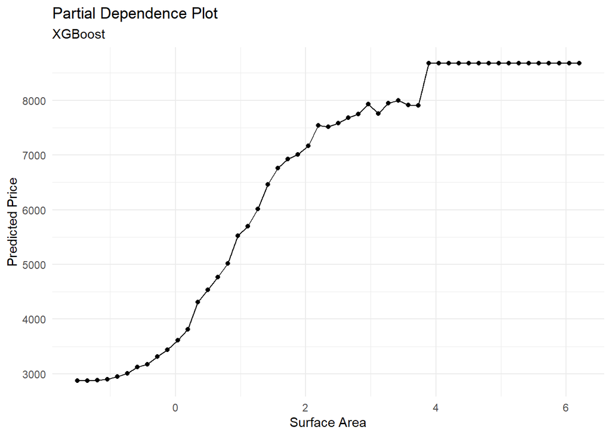

```r
rm(pdp_carat.rf, pdp_volume.rf, pdp_surface_area.rf)

# Partial Dependence Plot XGBoost
pdp_surface_area.xgb <- partial(xgb_engine, pred.var = "surface_area", train = diamonds_data.xgb)
pdp_volume.xgb <- partial(xgb_engine, pred.var = "volume", train = diamonds_data.xgb)
pdp_carat.xgb <- partial(xgb_engine, pred.var = "carat", train = diamonds_data.xgb)
pdp_depth.xgb <- partial(xgb_engine, pred.var = "depth", train = diamonds_data.xgb)
# Surface area
ggplot(pdp_surface_area.xgb, aes(x=surface_area, y=yhat)) +
  geom_point() +
  geom_line() +
  labs(title = "Partial Dependence Plot", subtitle = "XGBoost", x = "Surface Area", y = "Predicted Price") +
  theme_minimal()
```

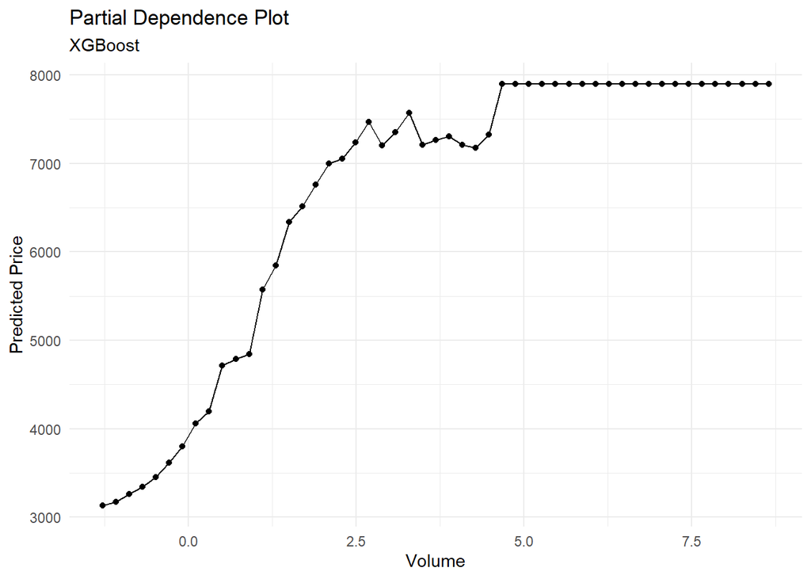

```r
# Volume
ggplot(pdp_volume.xgb, aes(x=volume, y=yhat)) +
  geom_point() +
  geom_line() +
  labs(title = "Partial Dependence Plot", subtitle = "XGBoost", x = "Volume", y = "Predicted Price") +
  theme_minimal()
```

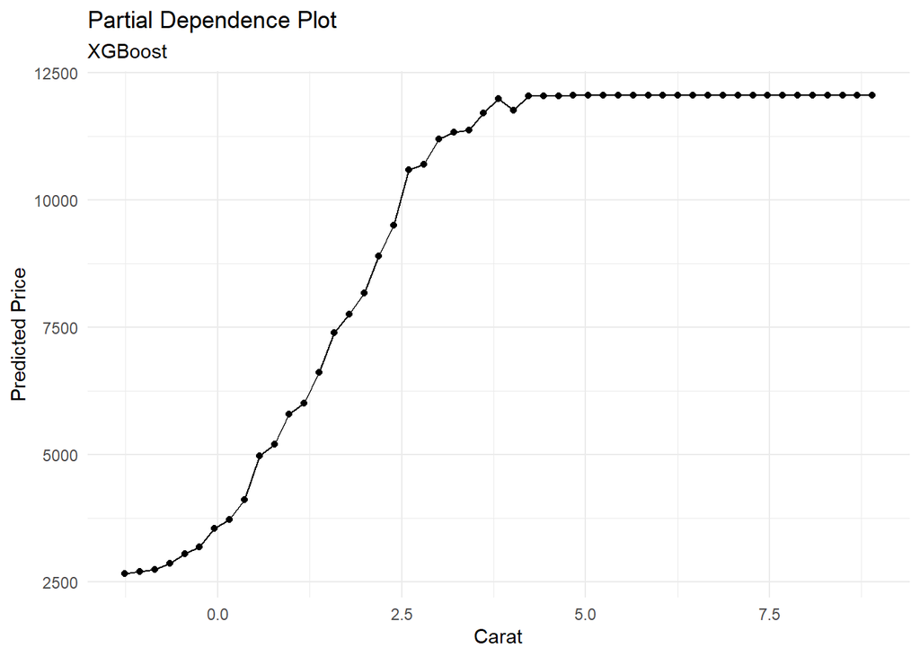

```r
# Carat
ggplot(pdp_carat.xgb, aes(x=carat, y=yhat)) +
  geom_point() +
  geom_line() +
  labs(title = "Partial Dependence Plot", subtitle = "XGBoost", x = "Carat", y = "Predicted Price") +
  theme_minimal()
```

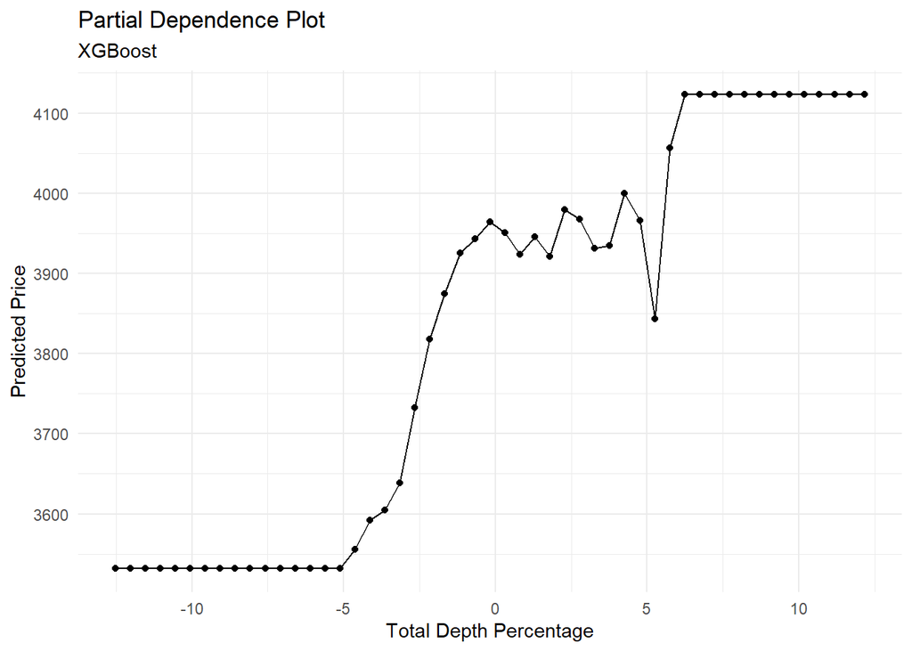

```r
ggplot(pdp_depth.xgb, aes(x=depth, y=yhat)) +
  geom_point() +
  geom_line() +
  labs(title = "Partial Dependence Plot", subtitle = "XGBoost", x = "Total Depth Percentage", y = "Predicted Price") +
  theme_minimal()
```

## Variable Importance Plots

### XGBoost

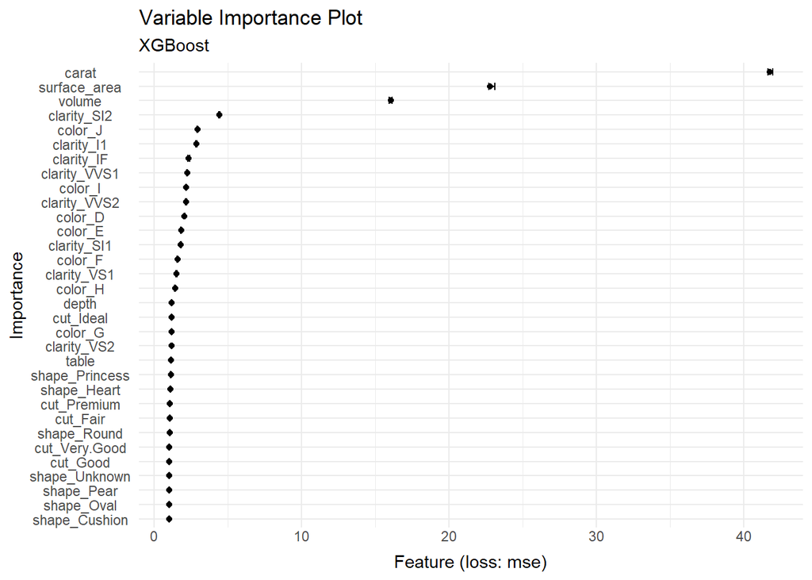

```r
rm(imp.rf, imp_data.rf, lower_ci.rf, upper_ci.rf)

# VIP xgboost
plan(callr, workers = 6)
imp.xgb <- FeatureImp$new(predictor.xgb, loss = "mse")
plan(sequential)
imp_data.xgb <- imp.xgb$results
lower_ci.xgb <- imp_data.xgb$importance.05
upper_ci.xgb <- imp_data.xgb$importance.95
ggplot(imp_data.xgb, aes(x = importance, y = reorder(feature, importance))) +
  geom_point(stat="identity", size=1.5, color="black") +
  geom_errorbar(aes(xmin = lower_ci.xgb, xmax = upper_ci.xgb), width = 0.5) +  # Adjust width as needed
  labs(title = "Variable Importance Plot", subtitle = "XGBoost", x = "Feature (loss: mse)", y = "Importance") +
  theme_minimal() +
  theme(axis.text.x = element_text(angle = 0, hjust = 0.5, vjust = 3),
        axis.text.y = element_text(hjust = 0.5))
```

## ALE Plots

### Random Forest

```r
rm(glmnet_coef, glmnet_vip)

plan(callr, workers=6)
# Surface Area
ale_surface_area.rf <- FeatureEffect$new(predictor.rf, feature = "surface_area", method='ale')
# Volume
ale_volume.rf <- FeatureEffect$new(predictor.rf, feature = "volume", method='ale')
# Total Depth Percentage
ale_depth.rf <- FeatureEffect$new(predictor.rf, feature = "depth", method='ale')
# Carat
ale_carat.rf <- FeatureEffect$new(predictor.rf, feature = "carat", method='ale')
plot(ale_surface_area.rf)
plot(ale_volume.rf)
plot(ale_carat.rf)
plot(ale_depth.rf)

plan(sequential)
```

[output not shown]

### XGBoost

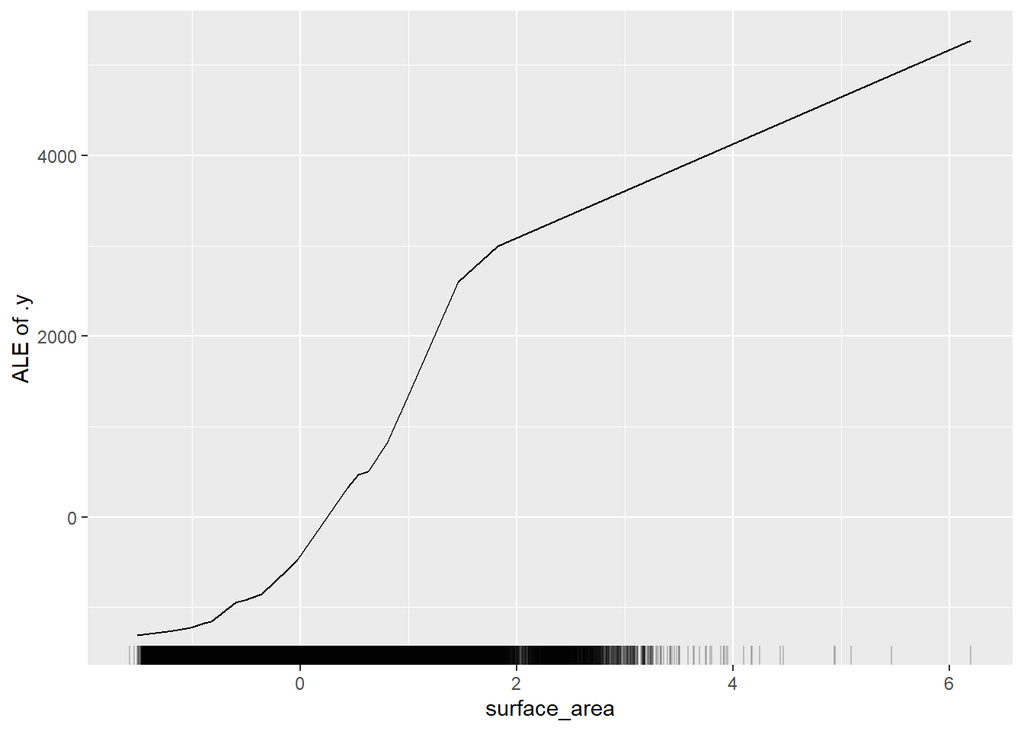

```r
rm(ale_surface_area.rf, ale_volume.rf, ale_carat.rf)
plan(callr, workers = 6)
## Surface Area
ale_surface_area.xgb <- FeatureEffect$new(predictor.xgb, feature = "surface_area", method='ale')
# Volume
ale_volume.xgb <- FeatureEffect$new(predictor.xgb, feature = "volume", method='ale')
# Carat
ale_carat.xgb <- FeatureEffect$new(predictor.xgb, feature = "carat", method='ale')
# Total Depth Percentage
ale_depth.xgb <- FeatureEffect$new(predictor.xgb, feature = "depth", method='ale')
plot(ale_surface_area.xgb)
```

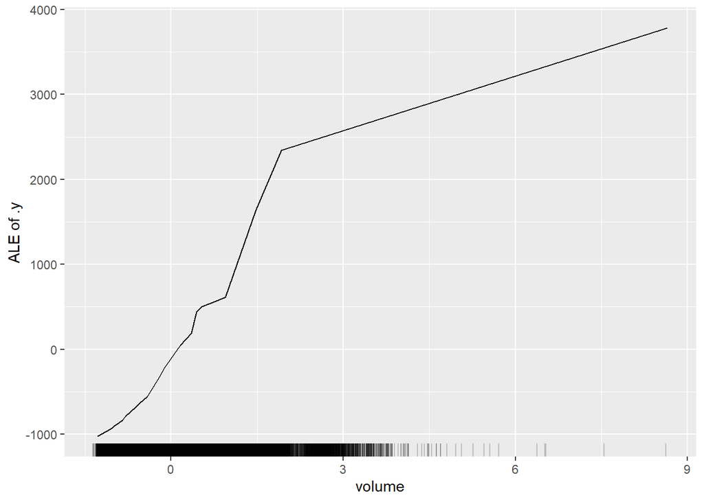

```r
plot(ale_volume.xgb)
```

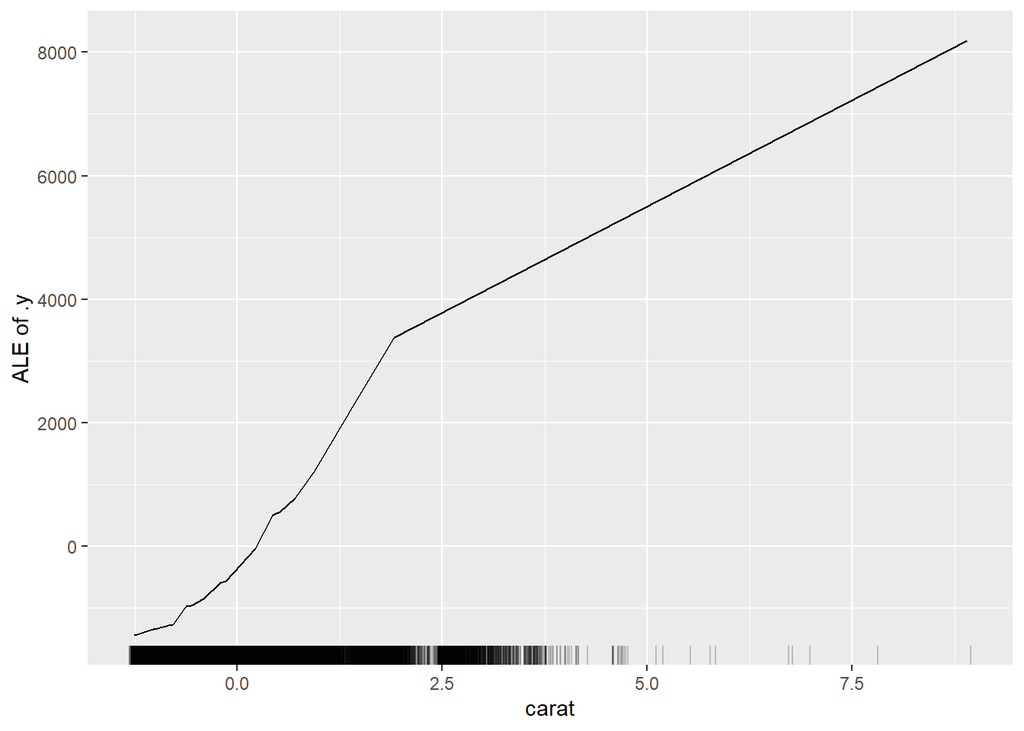

```r
plot(ale_carat.xgb)
```

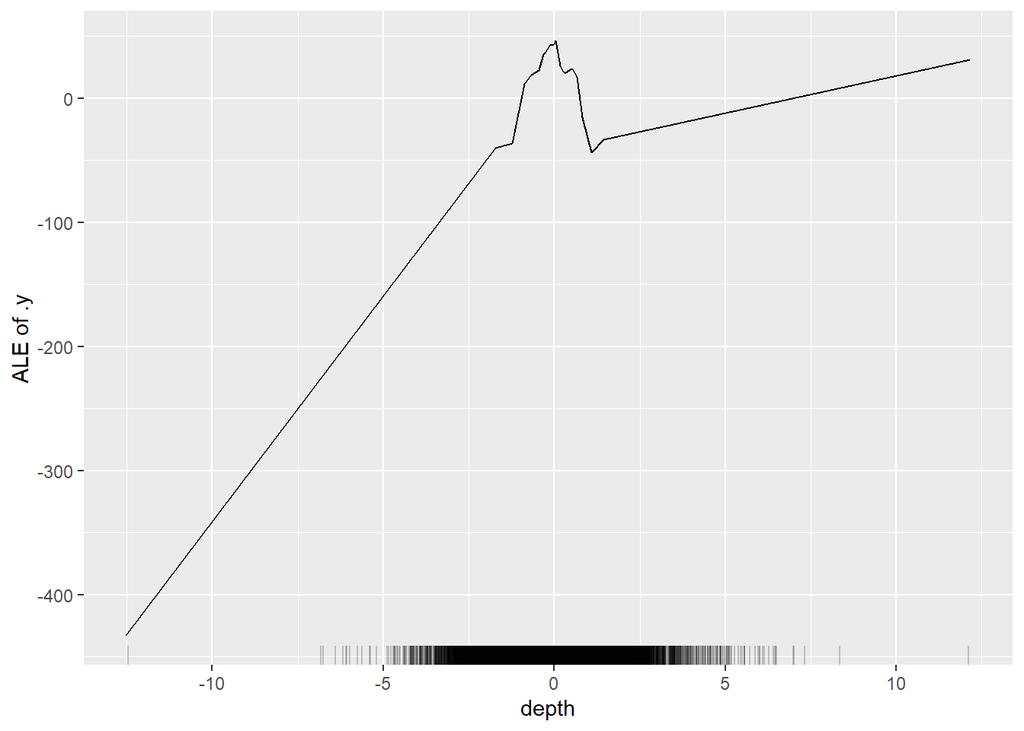

```r
plot(ale_depth.xgb)
```

```r
plan(sequential)
```

## Residuals vs Fitted Values (Penalized Regression)

```r
# Plotting Residuals vs. Fitted Values
ggplot(glmnet_residuals, aes(x = fitted, y = residual)) +
  geom_point(alpha = 0.5) +
  geom_hline(yintercept = 0, linetype = "dashed", color = "red") +
  labs(x = "Fitted Values", y = "Residuals", title = "Residuals vs Fitted Plot for Elastic Net Model") +
  theme_minimal()
```

[output not shown]